# Program Director Interviews

But I change the codebook a little, and there’s no to separate versions anymore. Sorry for the confusion :(

```r
#data <- read.delim(file.choose(),header = TRUE)
dataFA <-read.delim("./Binary_Factor.txt", header = TRUE)
#View(data)
```

```r
View(dataFA)
```

#CorrelationMatrix question: these correlations do not take into account statistical significance, right? Yes

```r
raqMatrix <- cor(dataFA[2:50])

head(round(raqMatrix, 2))
```

```
##                          Student_Choice Political_Problem
## Student_Choice                     1.00              0.87
## Political_Problem                  0.87              1.00
## No_negative_consequences           0.62              0.81
## FinishingDegreeisgood             -0.17             -0.09
## Getpromotedincareer                0.87              1.00
## LowCompletionRate                  0.08              0.27
##                          No_negative_consequences FinishingDegreeisgood
## Student_Choice                               0.62                 -0.17
## Political_Problem                            0.81                 -0.09
## No_negative_consequences                     1.00                  0.32
## FinishingDegreeisgood                        0.32                  1.00
## Getpromotedincareer                          0.81                 -0.09
## LowCompletionRate                            0.49                 -0.20
##                          Getpromotedincareer LowCompletionRate
## Student_Choice                          0.87              0.08
## Political_Problem                       1.00              0.27
## No_negative_consequences                0.81              0.49
## FinishingDegreeisgood                  -0.09             -0.20
## Getpromotedincareer                     1.00              0.27
## LowCompletionRate                       0.27              1.00
##                          University_Responsibility Less_Jobs
## Student_Choice                                0.00      0.87
## Political_Problem                            -0.13      1.00
## No_negative_consequences                     -0.24      0.81
## FinishingDegreeisgood                        -0.13     -0.09
## Getpromotedincareer                          -0.13      1.00
## LowCompletionRate                            -0.29      0.27
##                          Waste_of_Investments Missused_Opportunities
## Student_Choice                           0.56                  -0.17
## Political_Problem                        0.52                  -0.09
## No_negative_consequences                 0.62                  -0.16
## FinishingDegreeisgood                   -0.17                  -0.09
## Getpromotedincareer                      0.52                  -0.09
## LowCompletionRate                        0.53                   0.27
##                          University_Rankings Less_Popular_Specialisations
## Student_Choice                         -0.17                        -0.26
## Political_Problem                      -0.09                        -0.13
## No_negative_consequences                0.32                        -0.24
## FinishingDegreeisgood                  -0.09                        -0.13
```

[output cut: 106 more lines]

```
## LowCompletionRate                    0.27             0.37
##                          Reasonfor_Academic_Leaves Numberof_studentdropouts
## Student_Choice                                0.06                    -0.17
## Political_Problem                            -0.20                    -0.09
## No_negative_consequences                     -0.05                    -0.16
## FinishingDegreeisgood                        -0.20                    -0.09
## Getpromotedincareer                          -0.20                    -0.09
## LowCompletionRate                             0.16                     0.27
##                          Admission_Score Extracurricular_courses
## Student_Choice                     -0.17                    0.00
## Political_Problem                  -0.09                   -0.13
## No_negative_consequences           -0.16                   -0.24
## FinishingDegreeisgood              -0.09                   -0.13
## Getpromotedincareer                -0.09                   -0.13
## LowCompletionRate                   0.27                    0.06
```

question: Not sure whats going on here? If you un-comment and re-run, it gives an error

Answer: chances are you have another package attached that also has a select function and R thinks you are calling that. Thus; I changed it as dplyr::select. Now it should be work

```r
dataFA <- dplyr::select(dataFA, Student_Choice, Political_Problem,  No_negative_consequences,   FinishingDegreeisgood,  Getpromotedincareer,    LowCompletionRate,  University_Responsibility,  Less_Jobs,  Waste_of_Investments,   Missused_Opportunities, University_Rankings,    Less_Popular_Specialisations,   Boring_study_path,  Opportunity_to_Transfer,    Wrong_Speciality,   Extreme_Workload,   Family_issues,  Financial_Issues,   Health_Issues,  Psychological_social_Issues,    Hard_Curricular,    Learning_Difficulties,  Less_Support_from_Uni,  Employment, Thesis, Student_Supervisor_Relationship,    Perfectionism,  Track_Student_Behaviour,    Counseling, Academic_support_programs,  Inform_Relevant_People, Track_Dropouts, Supervisor_Communication,   Talk_to_Students,   Seminars_and_Courses,   Stuy_and_SelfManagement,    Curriculum_Development, Group_Discussions,  To_check_courseregistration,    Check_study_results,    Tax_office_data,    Industry_perspectives,  Qualitative_Data,   Previous_Studies,   Admission_Choice,   Reasonfor_Academic_Leaves,  Numberof_studentdropouts,   Admission_Score,    Extracurricular_courses,    credits_Nextsem_Previoussem,    LowGrades_FailedCourses,    Nextsem_Payments,   International_National_Clusters)
```

PCA to identify the number of factors

```r
dataFA.pca <- prcomp(dataFA)
summary(dataFA.pca)
```

```
## Importance of components:
##                           PC1    PC2    PC3    PC4    PC5     PC6     PC7
## Standard deviation     1.8192 1.6174 1.5419 1.2828 1.0269 0.84605 0.80854
## Proportion of Variance 0.2432 0.1923 0.1747 0.1210 0.0775 0.05261 0.04805
## Cumulative Proportion  0.2432 0.4355 0.6102 0.7312 0.8087 0.86127 0.90932
##                            PC8     PC9    PC10    PC11      PC12
## Standard deviation     0.69454 0.58583 0.49000 0.40999 4.688e-16
## Proportion of Variance 0.03545 0.02522 0.01765 0.01235 0.000e+00
## Cumulative Proportion  0.94478 0.97000 0.98765 1.00000 1.000e+00
```

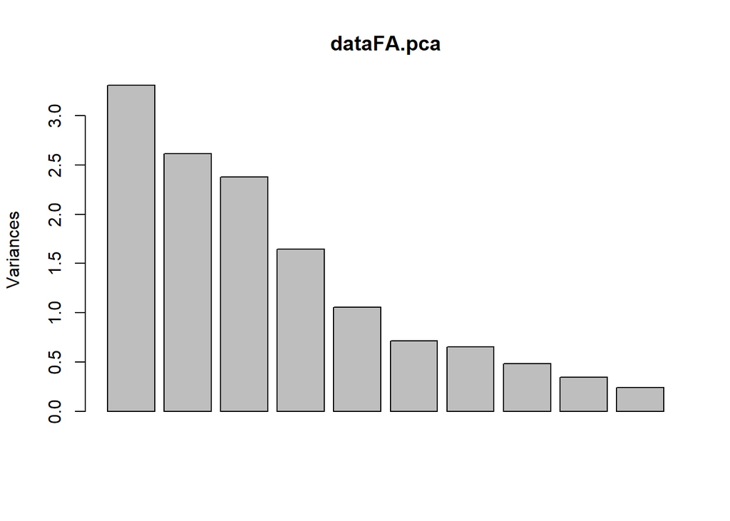

```r
plot(dataFA.pca)
```

Scree plot to find the number of factors

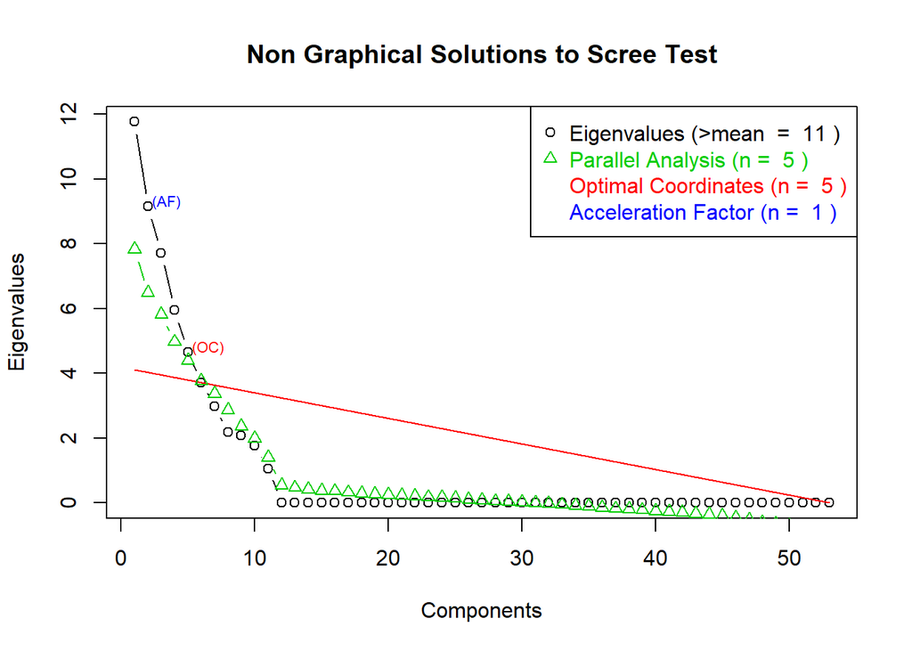

```r
ev <- eigen(cor(dataFA)) # get eigenvalues
ap <- parallel(subject=nrow(dataFA),var=ncol(dataFA),
               rep=100,cent=.05)
nS <- nScree(x=ev$values, aparallel=ap$eigen$qevpea)
plotnScree(nS)
```

I used Psych package’s fa.parallel function to execute the parallel analysis. The main goal of the parallel analysis is also to find out the number of factors.

[output not shown]

[output not shown]

[output not shown]

[output not shown]

[output not shown]

[output not shown]

[output not shown]

[output not shown]

[output not shown]

[output not shown]

[output not shown]

[output not shown]

[output not shown]

[output not shown]

[output not shown]

[output not shown]

[output not shown]

[output not shown]

[output not shown]

[output not shown]

[output not shown]

[output not shown]

[output not shown]

[output not shown]

[output not shown]

[output not shown]

[output not shown]

[output not shown]

[output not shown]

[output not shown]

[output not shown]

[output not shown]

[output not shown]

[output not shown]

[output not shown]

[output not shown]

[output not shown]

[output not shown]

[output not shown]

[output not shown]

[output not shown]

[output not shown]

[output not shown]

[output not shown]

[output not shown]

[output not shown]

[output not shown]

[output not shown]

[output not shown]

[output not shown]

[output not shown]

[output not shown]

[output not shown]

[output not shown]

[output not shown]

[output not shown]

[output not shown]

[output not shown]

[output not shown]

[output not shown]

[output not shown]

[output not shown]

[output not shown]

[output not shown]

[output not shown]

[output not shown]

[output not shown]

[output not shown]

[output not shown]

[output not shown]

[output not shown]

[output not shown]

[output not shown]

[output not shown]

[output not shown]

[output not shown]

[output not shown]

[output not shown]

[output not shown]

[output not shown]

[output not shown]

[output not shown]

[output not shown]

[output not shown]

[output not shown]

[output not shown]

[output not shown]

[output not shown]

[output not shown]

[output not shown]

[output not shown]

[output not shown]

[output not shown]

[output not shown]

[output not shown]

[output not shown]

[output not shown]

[output not shown]

[output not shown]

[output not shown]

[output not shown]

[output not shown]

[output not shown]

[output not shown]

[output not shown]

[output not shown]

[output not shown]

[output not shown]

[output not shown]

[output not shown]

[output not shown]

[output not shown]

[output not shown]

[output not shown]

[output not shown]

[output not shown]

[output not shown]

[output not shown]

[output not shown]

[output not shown]

[output not shown]

[output not shown]

[output not shown]

[output not shown]

[output not shown]

[output not shown]

[output not shown]

[output not shown]

[output not shown]

[output not shown]

[output not shown]

[output not shown]

[output not shown]

[output not shown]

[output not shown]

[output not shown]

[output not shown]

[output not shown]

[output not shown]

[output not shown]

[output not shown]

[output not shown]

[output not shown]

[output not shown]

[output not shown]

[output not shown]

[output not shown]

[output not shown]

[output not shown]

[output not shown]

[output not shown]

[output not shown]

[output not shown]

[output not shown]

[output not shown]

[output not shown]

[output not shown]

[output not shown]

[output not shown]

[output not shown]

[output not shown]

[output not shown]

[output not shown]

[output not shown]

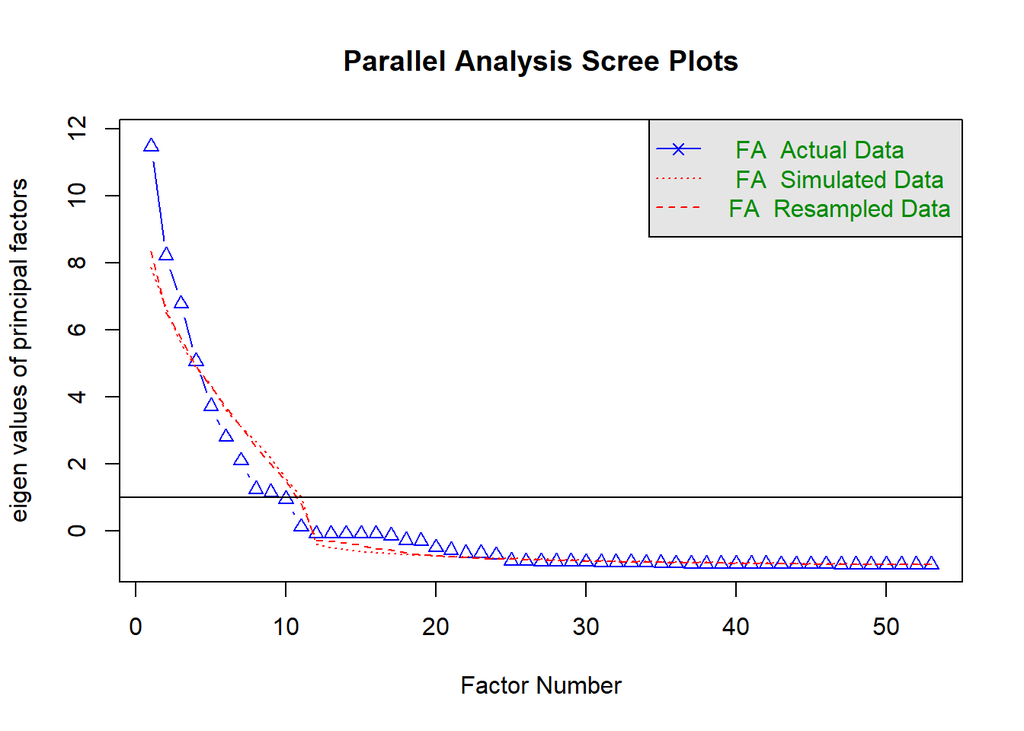

```
## Parallel analysis suggests that the number of factors =  3  and the number of components =  NA
```

```r
parallel<-fa.parallel(dataFA, fm='minres', fa='fa')
```

Parallel analysis suggests that the number of factors = 3 and the number of components = NA. Above 3 factors can describe as follows;

Factor 01: Political and Financial Issues Factor 02: Institutional Issues Factor 03: SOcietal Issues

Even though parallel analysis suggested to have 3 factors, based on the PCA data, I decided to run 4 factors.

library(nFactors)

```r
fourFA <- fa(dataFA,nfactors = 4,rotate = "oblimin",fm="minres")
```

```
## In smc, smcs < 0 were set to .0
## In smc, smcs < 0 were set to .0
## In smc, smcs < 0 were set to .0
```

```
## The determinant of the smoothed correlation was zero.
## This means the objective function is not defined.
## Chi square is based upon observed residuals.
```

```
## The determinant of the smoothed correlation was zero.
## This means the objective function is not defined for the null model either.
## The Chi square is thus based upon observed correlations.
```

```
## In factor.scores, the correlation matrix is singular, an approximation is used
```

```r
print(fourFA)
```

```
## Factor Analysis using method =  minres
## Call: fa(r = dataFA, nfactors = 4, rotate = "oblimin", fm = "minres")
## Standardized loadings (pattern matrix) based upon correlation matrix
##                                   MR1   MR2   MR3   MR4    h2    u2 com
## Student_Choice                   0.85 -0.18  0.20 -0.07 0.817 0.183 1.2
## Political_Problem                0.99 -0.06 -0.06  0.02 0.976 0.024 1.0
## No_negative_consequences         0.86  0.30 -0.02 -0.08 0.864 0.136 1.3
## FinishingDegreeisgood            0.02 -0.15 -0.02 -0.14 0.042 0.958 2.1
## Getpromotedincareer              0.99 -0.06 -0.06  0.02 0.976 0.024 1.0
## LowCompletionRate                0.35  0.83 -0.14  0.39 0.958 0.042 1.9
## University_Responsibility       -0.21 -0.16  0.64 -0.23 0.491 0.509 1.6
## Less_Jobs                        0.99 -0.06 -0.06  0.02 0.976 0.024 1.0
## Waste_of_Investments             0.51  0.53  0.58 -0.13 0.955 0.045 3.1
## Missused_Opportunities          -0.10  0.15 -0.47  0.02 0.253 0.747 1.3
## University_Rankings             -0.05  0.95  0.10 -0.06 0.917 0.083 1.0
## Less_Popular_Specialisations    -0.08 -0.13 -0.06  0.61 0.413 0.587 1.2
## Boring_study_path                0.18 -0.08  0.79 -0.15 0.686 0.314 1.2
## Opportunity_to_Transfer         -0.16  0.01 -0.45  0.52 0.492 0.508 2.1
## Wrong_Speciality                -0.06  0.25 -0.12  0.96 0.992 0.008 1.2
## Extreme_Workload                -0.15 -0.06  0.00 -0.13 0.039 0.961 2.3
## Family_issues                    0.70  0.67  0.03 -0.03 0.977 0.023 2.0
## Financial_Issues                 0.68 -0.23  0.00 -0.11 0.542 0.458 1.3
## Health_Issues                   -0.10 -0.08 -0.09  0.06 0.029 0.971 3.7
## Psychological_social_Issues     -0.19  0.32 -0.12 -0.16 0.171 0.829 2.5
## Hard_Curricular                 -0.17 -0.21  0.23  0.59 0.514 0.486 1.8
## Learning_Difficulties           -0.11  0.52  0.65  0.49 0.987 0.013 2.9
## Less_Support_from_Uni           -0.05  0.95  0.10 -0.06 0.917 0.083 1.0
## Employment                       0.88  0.09  0.26 -0.16 0.945 0.055 1.3
## Thesis                          -0.07 -0.16 -0.17 -0.13 0.078 0.922 3.2
## Student_Supervisor_Relationship -0.03 -0.24  0.05 -0.15 0.082 0.918 1.8
## Perfectionism                    0.99 -0.06 -0.06  0.02 0.976 0.024 1.0
## Track_Student_Behaviour         -0.10 -0.08 -0.09  0.06 0.029 0.971 3.7
## Counseling                      -0.14 -0.06  0.83 -0.15 0.697 0.303 1.1
## Academic_support_programs       -0.03 -0.12  0.00  0.93 0.894 0.106 1.0
## Inform_Relevant_People          -0.16  0.91 -0.19 -0.06 0.883 0.117 1.2
## Track_Dropouts                  -0.05  0.95  0.10 -0.06 0.917 0.083 1.0
## Supervisor_Communication        -0.05  0.95  0.10 -0.06 0.917 0.083 1.0
## Talk_to_Students                 0.05  0.25  0.88  0.21 0.917 0.083 1.3
## Seminars_and_Courses            -0.13 -0.21  0.78  0.21 0.733 0.267 1.4
## Stuy_and_SelfManagement         -0.13 -0.29  0.08 -0.23 0.151 0.849 2.5
```

[output cut: 33 more lines]

```
## Test of the hypothesis that 4 factors are sufficient.
##
## The degrees of freedom for the null model are  1378  and the objective function was  374.73 with Chi Square of  -2810.46
## The degrees of freedom for the model are 1172  and the objective function was  58.23
##
## The root mean square of the residuals (RMSR) is  0.13
## The df corrected root mean square of the residuals is  0.14
##
## The harmonic number of observations is  12 with the empirical chi square  547.67  with prob <  1
## The total number of observations was  12  with Likelihood Chi Square =  0  with prob <  1
##
## Tucker Lewis Index of factoring reliability =  0.6
## RMSEA index =  0  and the 90 % confidence intervals are  0 0
## BIC =  -3504.29
## Fit based upon off diagonal values = 0.86
```

```r
print(fourFA$loadings,cutoff = 0.3, sort=TRUE)
```

```
##
## Loadings:
##                                 MR1    MR2    MR3    MR4
## Student_Choice                   0.847
## Political_Problem                0.991
## No_negative_consequences         0.859
## Getpromotedincareer              0.991
## Less_Jobs                        0.991
## Family_issues                    0.701  0.668
## Financial_Issues                 0.685
## Employment                       0.885
## Perfectionism                    0.991
## Tax_office_data                  0.991
## Industry_perspectives            0.991
## Qualitative_Data                 0.628        -0.395
## International_National_Clusters  0.723
## LowCompletionRate                0.350  0.834         0.393
## University_Rankings                     0.950
## Less_Support_from_Uni                   0.950
## Inform_Relevant_People                  0.910
## Track_Dropouts                          0.950
## Supervisor_Communication                0.950
## To_check_courseregistration             0.637
## Check_study_results                     0.808
## Admission_Choice                        0.533 -0.476
## University_Responsibility                      0.643
## Waste_of_Investments             0.508  0.534  0.576
## Boring_study_path                              0.790
## Learning_Difficulties                   0.519  0.646  0.488
## Counseling                                     0.828
## Talk_to_Students                               0.878
## Seminars_and_Courses                           0.784
## Curriculum_Development           0.370 -0.423  0.502
## Group_Discussions                              0.828
## Reasonfor_Academic_Leaves               0.473  0.517
## credits_Nextsem_Previoussem                   -0.548
## LowGrades_FailedCourses                        0.553  0.404
## Less_Popular_Specialisations                          0.613
## Opportunity_to_Transfer                       -0.445  0.523
## Wrong_Speciality                                      0.957
## Hard_Curricular                                       0.591
## Academic_support_programs                             0.934
## Previous_Studies                                      0.984
## Numberof_studentdropouts                              0.984
## Extracurricular_courses                               0.734
## FinishingDegreeisgood
## Missused_Opportunities                        -0.468
## Extreme_Workload
## Health_Issues
## Psychological_social_Issues             0.322
## Thesis
## Student_Supervisor_Relationship
## Track_Student_Behaviour
## Stuy_and_SelfManagement
## Admission_Score                               -0.468
## Nextsem_Payments
##
##                   MR1   MR2   MR3   MR4
## SS loadings    11.146 8.806 7.278 6.382
## Proportion Var  0.210 0.166 0.137 0.120
## Cumulative Var  0.210 0.376 0.514 0.634
```

Based on the above factor loading, factors can describe as follows; Factor 01: Societal Factors Factor 02: INstitutional Support Factor 03: Learning Difficulties Factor 04: Disposition (Attitude towards the studies)

#————-Latent Class Analysis——————

```r
library(scatterplot3d)
library(MASS)
library(poLCA)
library(xlsx)
library("reshape2")
library("plyr")
library("dplyr")
library("poLCA")
library("ggplot2")
library("ggparallel")
library("igraph")
library("tidyr")
library("knitr")
```

Here as you mentioned I considered participant statement as the unit of analysis

```r
lca.data <-read.delim("./BinaryNew.txt",header = TRUE)
```

[output not shown]

[output cut: 45 more lines]

```
## Model 86: llik = -222.3383 ... best llik = -217.5124
## Model 87: llik = -221.0092 ... best llik = -217.5124
## Model 88: llik = -222.9877 ... best llik = -217.5124
## Model 89: llik = -221.4341 ... best llik = -217.5124
## Model 90: llik = -224.1301 ... best llik = -217.5124
## Model 91: llik = -221.2975 ... best llik = -217.5124
## Model 92: llik = -222.2286 ... best llik = -217.5124
## Model 93: llik = -223.5399 ... best llik = -217.5124
## Model 94: llik = -221.8076 ... best llik = -217.5124
## Model 95: llik = -226.5468 ... best llik = -217.5124
## Model 96: llik = -224.5153 ... best llik = -217.5124
## Model 97: llik = -222.5233 ... best llik = -217.5124
## Model 98: llik = -223.9007 ... best llik = -217.5124
## Model 99: llik = -221.1994 ... best llik = -217.5124
## Model 100: llik = -224.0053 ... best llik = -217.5124
```

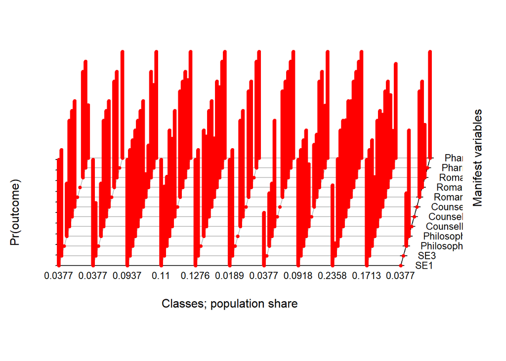

```
## Conditional item response (column) probabilities,
##  by outcome variable, for each class (row)
##
## $SE1
##             Pr(1)  Pr(2)
## class 1:   0.0000 1.0000
## class 2:   0.0000 1.0000
## class 3:   0.0000 1.0000
## class 4:   0.0000 1.0000
## class 5:   0.0000 1.0000
## class 6:   0.0000 1.0000
## class 7:   0.5000 0.5000
## class 8:   0.0000 1.0000
## class 9:   0.2401 0.7599
## class 10:  0.0000 1.0000
## class 11:  1.0000 0.0000
##
## $SE3
##             Pr(1)  Pr(2)
## class 1:   0.0000 1.0000
## class 2:   0.5000 0.5000
## class 3:   0.0000 1.0000
## class 4:   0.3429 0.6571
## class 5:   0.0000 1.0000
## class 6:   0.0000 1.0000
## class 7:   1.0000 0.0000
## class 8:   0.0000 1.0000
## class 9:   0.8803 0.1197
## class 10:  0.0000 1.0000
## class 11:  1.0000 0.0000
##
## $Philosophy2
##             Pr(1)  Pr(2)
## class 1:   1.0000 0.0000
## class 2:   1.0000 0.0000
## class 3:   0.0000 1.0000
## class 4:   0.3429 0.6571
## class 5:   1.0000 0.0000
## class 6:   1.0000 0.0000
## class 7:   0.5000 0.5000
```

[output cut: 139 more lines]

```
## =========================================================
## number of observations: 53
## number of estimated parameters: 142
## residual degrees of freedom: -89
## maximum log-likelihood: -217.5124
##
## AIC(11): 719.0248
## BIC(11): 998.8062
## G^2(11): 60.62823 (Likelihood ratio/deviance statistic)
## X^2(11): 63.88948 (Chi-square goodness of fit)
##
## ALERT: number of parameters estimated ( 142 ) exceeds number of observations ( 53 )
##
## ALERT: negative degrees of freedom; respecify model
##
```

```r
lca11<- poLCA(cbind(SE1,    SE3,    Philosophy2,    Philosophy3,    Counselling1,   Counselling2,   Counselling3,   Romance2,   Romance3,   Romance4,   Pharmacy2,  Pharmacy3)~1, lca.data, nclass=11, nrep = 100, na.rm=FALSE, graphs=T)
```

```r
lca11$predclass
```

```
##  [1]  7  9  9  9  9  2  4  9  4  3  5 10  4  3  2 10  9  9 10  5  8  4  5  7  8
## [26]  8  9 10  4 10  1  5  5 11  8  8 11  4  5  5  9  9  9 10  1  6 10  3 10  3
## [51] 10  3  9
```

Here I tried to give a name for the classes based on the underlying semantics

Class 01: {Disposition(Attitude towards study)}

Class 02: {Personal and financial Reasons}

Student_Choice, Employment

Class 03: {Institutional support}

Class 04: {Student behaviour}

CLass 05: {Student-University Interaction/Student Satisfaction}

Class 06: {Academic Outcomes}

Class 07: {Stress}

Class 08: {Political Concerns}

Class 09: {Mental support}

Class 10: {Wrong studiy choices}

CLass 11: {Curriculum Concerns}

Hard_Curricular, Seminars_and_Courses

Select variable and define function for all codes

```r
mylcadata <- lca.data %>% dplyr::select(SE1,    SE3,    Philosophy2,    Philosophy3,    Counselling1,   Counselling2,   Counselling3,   Romance2,   Romance3,   Romance4,   Pharmacy2,  Pharmacy3)

f<-with(mylcadata, cbind(SE1,   SE3,    Philosophy2,    Philosophy3,    Counselling1,   Counselling2,   Counselling3,   Romance2,   Romance3,   Romance4,   Pharmacy2,  Pharmacy3)~1)
```

models with different number of groups

```r
set.seed(01012)
lc1<-poLCA(f, data=mylcadata, nclass=1, na.rm = FALSE, nrep=30, maxiter=3000) #Loglinear independence model.
```

```
## Conditional item response (column) probabilities,
##  by outcome variable, for each class (row)
##
## $SE1
##            Pr(1)  Pr(2)
## class 1:  0.1132 0.8868
##
## $SE3
##            Pr(1)  Pr(2)
## class 1:  0.3396 0.6604
##
## $Philosophy2
##            Pr(1)  Pr(2)
## class 1:  0.3396 0.6604
##
## $Philosophy3
##            Pr(1)  Pr(2)
## class 1:  0.1509 0.8491
##
## $Counselling1
##            Pr(1)  Pr(2)
## class 1:  0.1132 0.8868
##
## $Counselling2
##            Pr(1)  Pr(2)
## class 1:  0.1887 0.8113
##
## $Counselling3
##            Pr(1)  Pr(2)
## class 1:  0.2642 0.7358
##
## $Romance2
##            Pr(1)  Pr(2)
## class 1:  0.2642 0.7358
##
## $Romance3
##            Pr(1)  Pr(2)
## class 1:  0.0943 0.9057
##
## $Romance4
```

[output cut: 15 more lines]

```
##  1
##
## =========================================================
## Fit for 1 latent classes:
## =========================================================
## number of observations: 53
## number of estimated parameters: 12
## residual degrees of freedom: 41
## maximum log-likelihood: -286.9539
##
## AIC(1): 597.9078
## BIC(1): 621.5513
## G^2(1): 199.5113 (Likelihood ratio/deviance statistic)
## X^2(1): 20856.26 (Chi-square goodness of fit)
##
```

```r
lc2<-poLCA(f, data=mylcadata, nclass=2, na.rm = FALSE, nrep=30, maxiter=3000)
```

```
## Model 1: llik = -271.7811 ... best llik = -271.7811
## Model 2: llik = -283.8428 ... best llik = -271.7811
## Model 3: llik = -271.7811 ... best llik = -271.7811
## Model 4: llik = -271.7811 ... best llik = -271.7811
## Model 5: llik = -271.3177 ... best llik = -271.3177
## Model 6: llik = -270.6877 ... best llik = -270.6877
## Model 7: llik = -271.7811 ... best llik = -270.6877
## Model 8: llik = -272.8809 ... best llik = -270.6877
## Model 9: llik = -272.0719 ... best llik = -270.6877
## Model 10: llik = -271.3177 ... best llik = -270.6877
## Model 11: llik = -272.0719 ... best llik = -270.6877
## Model 12: llik = -271.7811 ... best llik = -270.6877
## Model 13: llik = -272.1228 ... best llik = -270.6877
## Model 14: llik = -271.3177 ... best llik = -270.6877
## Model 15: llik = -271.3177 ... best llik = -270.6877
## Model 16: llik = -272.8809 ... best llik = -270.6877
## Model 17: llik = -271.3177 ... best llik = -270.6877
## Model 18: llik = -272.0719 ... best llik = -270.6877
## Model 19: llik = -272.0719 ... best llik = -270.6877
## Model 20: llik = -277.4737 ... best llik = -270.6877
## Model 21: llik = -271.7811 ... best llik = -270.6877
## Model 22: llik = -271.7811 ... best llik = -270.6877
## Model 23: llik = -271.7811 ... best llik = -270.6877
## Model 24: llik = -272.0719 ... best llik = -270.6877
## Model 25: llik = -271.7811 ... best llik = -270.6877
## Model 26: llik = -271.7811 ... best llik = -270.6877
## Model 27: llik = -272.0719 ... best llik = -270.6877
## Model 28: llik = -271.7811 ... best llik = -270.6877
## Model 29: llik = -272.8809 ... best llik = -270.6877
## Model 30: llik = -271.7811 ... best llik = -270.6877
## Conditional item response (column) probabilities,
##  by outcome variable, for each class (row)
##
## $SE1
##            Pr(1)  Pr(2)
## class 1:  0.0604 0.9396
## class 2:  1.0000 0.0000
##
## $SE3
##            Pr(1)  Pr(2)
```

[output cut: 57 more lines]

```
##  0.9434 0.0566
##
## =========================================================
## Fit for 2 latent classes:
## =========================================================
## number of observations: 53
## number of estimated parameters: 25
## residual degrees of freedom: 28
## maximum log-likelihood: -270.6877
##
## AIC(2): 591.3753
## BIC(2): 640.6326
## G^2(2): 166.9788 (Likelihood ratio/deviance statistic)
## X^2(2): 1036.736 (Chi-square goodness of fit)
##
```

```r
lc3<-poLCA(f, data=mylcadata, nclass=3, na.rm = FALSE, nrep=30, maxiter=3000)
```

```
## Model 1: llik = -259.3618 ... best llik = -259.3618
## Model 2: llik = -260.4036 ... best llik = -259.3618
## Model 3: llik = -265.8833 ... best llik = -259.3618
## Model 4: llik = -265.3061 ... best llik = -259.3618
## Model 5: llik = -259.0021 ... best llik = -259.0021
## Model 6: llik = -260.0619 ... best llik = -259.0021
## Model 7: llik = -260.3941 ... best llik = -259.0021
## Model 8: llik = -257.8846 ... best llik = -257.8846
## Model 9: llik = -260.9298 ... best llik = -257.8846
## Model 10: llik = -257.8846 ... best llik = -257.8846
## Model 11: llik = -259.7029 ... best llik = -257.8846
## Model 12: llik = -257.8846 ... best llik = -257.8846
## Model 13: llik = -264.7944 ... best llik = -257.8846
## Model 14: llik = -262.1734 ... best llik = -257.8846
## Model 15: llik = -257.8846 ... best llik = -257.8846
## Model 16: llik = -260.3941 ... best llik = -257.8846
## Model 17: llik = -259.5091 ... best llik = -257.8846
## Model 18: llik = -258.3944 ... best llik = -257.8846
## Model 19: llik = -265.1784 ... best llik = -257.8846
## Model 20: llik = -259.0021 ... best llik = -257.8846
## Model 21: llik = -260.3941 ... best llik = -257.8846
## Model 22: llik = -259.6964 ... best llik = -257.8846
## Model 23: llik = -259.0021 ... best llik = -257.8846
## Model 24: llik = -260.3456 ... best llik = -257.8846
## Model 25: llik = -258.3944 ... best llik = -257.8846
## Model 26: llik = -260.0232 ... best llik = -257.8846
## Model 27: llik = -266.7285 ... best llik = -257.8846
## Model 28: llik = -260.9298 ... best llik = -257.8846
## Model 29: llik = -260.3941 ... best llik = -257.8846
## Model 30: llik = -258.2267 ... best llik = -257.8846
## Conditional item response (column) probabilities,
##  by outcome variable, for each class (row)
##
## $SE1
##            Pr(1)  Pr(2)
## class 1:  0.1746 0.8254
## class 2:  0.5000 0.5000
## class 3:  0.0000 1.0000
##
## $SE3
```

[output cut: 69 more lines]

```
##  0.4151 0.0755 0.5094
##
## =========================================================
## Fit for 3 latent classes:
## =========================================================
## number of observations: 53
## number of estimated parameters: 38
## residual degrees of freedom: 15
## maximum log-likelihood: -257.8846
##
## AIC(3): 591.7693
## BIC(3): 666.6404
## G^2(3): 141.3727 (Likelihood ratio/deviance statistic)
## X^2(3): 384.0479 (Chi-square goodness of fit)
##
```

```r
lc4<-poLCA(f, data=mylcadata, nclass=4, na.rm = FALSE, nrep=30, maxiter=3000)
```

```
## Model 1: llik = -254.2794 ... best llik = -254.2794
## Model 2: llik = -254.9004 ... best llik = -254.2794
## Model 3: llik = -252.7478 ... best llik = -252.7478
## Model 4: llik = -256.6714 ... best llik = -252.7478
## Model 5: llik = -249.1996 ... best llik = -249.1996
## Model 6: llik = -249.0691 ... best llik = -249.0691
## Model 7: llik = -249.1809 ... best llik = -249.0691
## Model 8: llik = -249.4245 ... best llik = -249.0691
## Model 9: llik = -249.6524 ... best llik = -249.0691
## Model 10: llik = -251.5097 ... best llik = -249.0691
## Model 11: llik = -252.5948 ... best llik = -249.0691
## Model 12: llik = -249.0691 ... best llik = -249.0691
## Model 13: llik = -252.2596 ... best llik = -249.0691
## Model 14: llik = -249.4245 ... best llik = -249.0691
## Model 15: llik = -252.3098 ... best llik = -249.0691
## Model 16: llik = -249.9743 ... best llik = -249.0691
## Model 17: llik = -248.3884 ... best llik = -248.3884
## Model 18: llik = -251.491 ... best llik = -248.3884
## Model 19: llik = -249.1996 ... best llik = -248.3884
## Model 20: llik = -249.0691 ... best llik = -248.3884
## Model 21: llik = -252.5122 ... best llik = -248.3884
## Model 22: llik = -261.4321 ... best llik = -248.3884
## Model 23: llik = -251.5097 ... best llik = -248.3884
## Model 24: llik = -249.7609 ... best llik = -248.3884
## Model 25: llik = -253.6211 ... best llik = -248.3884
## Model 26: llik = -255.938 ... best llik = -248.3884
## Model 27: llik = -253.6211 ... best llik = -248.3884
## Model 28: llik = -254.0715 ... best llik = -248.3884
## Model 29: llik = -249.0523 ... best llik = -248.3884
## Model 30: llik = -262.3536 ... best llik = -248.3884
## Conditional item response (column) probabilities,
##  by outcome variable, for each class (row)
##
## $SE1
##            Pr(1)  Pr(2)
## class 1:  0.2382 0.7618
## class 2:  0.0000 1.0000
## class 3:  0.0000 1.0000
## class 4:  0.6667 0.3333
##
```

[output cut: 81 more lines]

```
##  0.283 0.3396 0.3208 0.0566
##
## =========================================================
## Fit for 4 latent classes:
## =========================================================
## number of observations: 53
## number of estimated parameters: 51
## residual degrees of freedom: 2
## maximum log-likelihood: -248.3884
##
## AIC(4): 598.7769
## BIC(4): 699.2618
## G^2(4): 122.3804 (Likelihood ratio/deviance statistic)
## X^2(4): 264.1003 (Chi-square goodness of fit)
##
```

```r
lc5<-poLCA(f, data=mylcadata, nclass=5, na.rm = FALSE, nrep=30, maxiter=3000)
```

```
## Model 1: llik = -241.0416 ... best llik = -241.0416
## Model 2: llik = -241.0416 ... best llik = -241.0416
## Model 3: llik = -250.4338 ... best llik = -241.0416
## Model 4: llik = -241.0416 ... best llik = -241.0416
## Model 5: llik = -241.0416 ... best llik = -241.0416
## Model 6: llik = -246.3493 ... best llik = -241.0416
## Model 7: llik = -246.2127 ... best llik = -241.0416
## Model 8: llik = -245.632 ... best llik = -241.0416
## Model 9: llik = -240.8338 ... best llik = -240.8338
## Model 10: llik = -248.914 ... best llik = -240.8338
## Model 11: llik = -240.8338 ... best llik = -240.8338
## Model 12: llik = -244.0749 ... best llik = -240.8338
## Model 13: llik = -244.8409 ... best llik = -240.8338
## Model 14: llik = -253.3883 ... best llik = -240.8338
## Model 15: llik = -246.6643 ... best llik = -240.8338
## Model 16: llik = -252.2473 ... best llik = -240.8338
## Model 17: llik = -243.9089 ... best llik = -240.8338
## Model 18: llik = -250.3886 ... best llik = -240.8338
## Model 19: llik = -248.5313 ... best llik = -240.8338
## Model 20: llik = -241.8437 ... best llik = -240.8338
## Model 21: llik = -244.5447 ... best llik = -240.8338
## Model 22: llik = -245.9823 ... best llik = -240.8338
## Model 23: llik = -245.0497 ... best llik = -240.8338
## Model 24: llik = -245.7331 ... best llik = -240.8338
## Model 25: llik = -244.0262 ... best llik = -240.8338
## Model 26: llik = -247.8071 ... best llik = -240.8338
## Model 27: llik = -249.6625 ... best llik = -240.8338
## Model 28: llik = -246.7473 ... best llik = -240.8338
## Model 29: llik = -248.0962 ... best llik = -240.8338
## Model 30: llik = -241.5917 ... best llik = -240.8338
## Conditional item response (column) probabilities,
##  by outcome variable, for each class (row)
##
## $SE1
##            Pr(1)  Pr(2)
## class 1:  0.0000 1.0000
## class 2:  1.0000 0.0000
## class 3:  0.0000 1.0000
## class 4:  0.1877 0.8123
## class 5:  0.0000 1.0000
```

[output cut: 97 more lines]

```
## =========================================================
## number of observations: 53
## number of estimated parameters: 64
## residual degrees of freedom: -11
## maximum log-likelihood: -240.8338
##
## AIC(5): 609.6677
## BIC(5): 735.7663
## G^2(5): 107.2711 (Likelihood ratio/deviance statistic)
## X^2(5): 196.9142 (Chi-square goodness of fit)
##
## ALERT: number of parameters estimated ( 64 ) exceeds number of observations ( 53 )
##
## ALERT: negative degrees of freedom; respecify model
##
```

```r
lc6<-poLCA(f, data=mylcadata, nclass=6, na.rm = FALSE, nrep=30, maxiter=3000)
```

```
## Model 1: llik = -241.2483 ... best llik = -241.2483
## Model 2: llik = -238.2932 ... best llik = -238.2932
## Model 3: llik = -238.4709 ... best llik = -238.2932
## Model 4: llik = -236.9573 ... best llik = -236.9573
## Model 5: llik = -238.9877 ... best llik = -236.9573
## Model 6: llik = -237.8592 ... best llik = -236.9573
## Model 7: llik = -236.8282 ... best llik = -236.8282
## Model 8: llik = -237.4378 ... best llik = -236.8282
## Model 9: llik = -236.7375 ... best llik = -236.7375
## Model 10: llik = -238.6196 ... best llik = -236.7375
## Model 11: llik = -237.1751 ... best llik = -236.7375
## Model 12: llik = -238.0502 ... best llik = -236.7375
## Model 13: llik = -239.3097 ... best llik = -236.7375
## Model 14: llik = -252.3648 ... best llik = -236.7375
## Model 15: llik = -242.0284 ... best llik = -236.7375
## Model 16: llik = -237.9833 ... best llik = -236.7375
## Model 17: llik = -239.0469 ... best llik = -236.7375
## Model 18: llik = -242.6775 ... best llik = -236.7375
## Model 19: llik = -237.5824 ... best llik = -236.7375
## Model 20: llik = -241.5078 ... best llik = -236.7375
## Model 21: llik = -244.3411 ... best llik = -236.7375
## Model 22: llik = -238.1178 ... best llik = -236.7375
## Model 23: llik = -238.4893 ... best llik = -236.7375
## Model 24: llik = -242.4975 ... best llik = -236.7375
## Model 25: llik = -241.4185 ... best llik = -236.7375
## Model 26: llik = -242.6703 ... best llik = -236.7375
## Model 27: llik = -240.2471 ... best llik = -236.7375
## Model 28: llik = -237.443 ... best llik = -236.7375
## Model 29: llik = -239.1021 ... best llik = -236.7375
## Model 30: llik = -244.3769 ... best llik = -236.7375
## Conditional item response (column) probabilities,
##  by outcome variable, for each class (row)
##
## $SE1
##            Pr(1)  Pr(2)
## class 1:  1.0000 0.0000
## class 2:  0.0000 1.0000
## class 3:  0.2474 0.7526
## class 4:  0.0000 1.0000
## class 5:  0.0000 1.0000
```

[output cut: 109 more lines]

```
## =========================================================
## number of observations: 53
## number of estimated parameters: 77
## residual degrees of freedom: -24
## maximum log-likelihood: -236.7375
##
## AIC(6): 627.475
## BIC(6): 779.1874
## G^2(6): 99.07844 (Likelihood ratio/deviance statistic)
## X^2(6): 181.7077 (Chi-square goodness of fit)
##
## ALERT: number of parameters estimated ( 77 ) exceeds number of observations ( 53 )
##
## ALERT: negative degrees of freedom; respecify model
##
```

```r
lc7<-poLCA(f, data=mylcadata, nclass=7, na.rm = FALSE, nrep=30, maxiter=3000)
```

```
## Model 1: llik = -237.8362 ... best llik = -237.8362
## Model 2: llik = -238.5309 ... best llik = -237.8362
## Model 3: llik = -234.9277 ... best llik = -234.9277
## Model 4: llik = -237.9924 ... best llik = -234.9277
## Model 5: llik = -234.6019 ... best llik = -234.6019
## Model 6: llik = -235.4836 ... best llik = -234.6019
## Model 7: llik = -233.8748 ... best llik = -233.8748
## Model 8: llik = -236.0868 ... best llik = -233.8748
## Model 9: llik = -235.4283 ... best llik = -233.8748
## Model 10: llik = -242.0844 ... best llik = -233.8748
## Model 11: llik = -235.1777 ... best llik = -233.8748
## Model 12: llik = -240.7046 ... best llik = -233.8748
## Model 13: llik = -234.031 ... best llik = -233.8748
## Model 14: llik = -234.6456 ... best llik = -233.8748
## Model 15: llik = -233.0522 ... best llik = -233.0522
## Model 16: llik = -240.9144 ... best llik = -233.0522
## Model 17: llik = -235.8954 ... best llik = -233.0522
## Model 18: llik = -239.9144 ... best llik = -233.0522
## Model 19: llik = -234.7337 ... best llik = -233.0522
## Model 20: llik = -241.667 ... best llik = -233.0522
## Model 21: llik = -234.9467 ... best llik = -233.0522
## Model 22: llik = -236.7749 ... best llik = -233.0522
## Model 23: llik = -237.7727 ... best llik = -233.0522
## Model 24: llik = -232.6578 ... best llik = -232.6578
## Model 25: llik = -236.526 ... best llik = -232.6578
## Model 26: llik = -234.9857 ... best llik = -232.6578
## Model 27: llik = -235.6073 ... best llik = -232.6578
## Model 28: llik = -235.4271 ... best llik = -232.6578
## Model 29: llik = -234.8729 ... best llik = -232.6578
## Model 30: llik = -238.4588 ... best llik = -232.6578
## Conditional item response (column) probabilities,
##  by outcome variable, for each class (row)
##
## $SE1
##            Pr(1)  Pr(2)
## class 1:  0.0000 1.0000
## class 2:  1.0000 0.0000
## class 3:  0.2075 0.7925
## class 4:  0.0000 1.0000
## class 5:  0.0000 1.0000
```

[output cut: 121 more lines]

```
## =========================================================
## number of observations: 53
## number of estimated parameters: 90
## residual degrees of freedom: -37
## maximum log-likelihood: -232.6578
##
## AIC(7): 645.3157
## BIC(7): 822.642
## G^2(7): 90.91916 (Likelihood ratio/deviance statistic)
## X^2(7): 154.7633 (Chi-square goodness of fit)
##
## ALERT: number of parameters estimated ( 90 ) exceeds number of observations ( 53 )
##
## ALERT: negative degrees of freedom; respecify model
##
```

```r
lc8<-poLCA(f, data=mylcadata, nclass=8, na.rm = FALSE, nrep=30, maxiter=3000)
```

```
## Model 1: llik = -231.1814 ... best llik = -231.1814
## Model 2: llik = -237.9104 ... best llik = -231.1814
## Model 3: llik = -234.7253 ... best llik = -231.1814
## Model 4: llik = -231.0153 ... best llik = -231.0153
## Model 5: llik = -233.4641 ... best llik = -231.0153
## Model 6: llik = -230.844 ... best llik = -230.844
## Model 7: llik = -229.8919 ... best llik = -229.8919
## Model 8: llik = -233.1845 ... best llik = -229.8919
## Model 9: llik = -233.7718 ... best llik = -229.8919
## Model 10: llik = -235.0517 ... best llik = -229.8919
## Model 11: llik = -229.6888 ... best llik = -229.6888
## Model 12: llik = -233.4047 ... best llik = -229.6888
## Model 13: llik = -231.884 ... best llik = -229.6888
## Model 14: llik = -231.2516 ... best llik = -229.6888
## Model 15: llik = -236.6772 ... best llik = -229.6888
## Model 16: llik = -232.1679 ... best llik = -229.6888
## Model 17: llik = -234.5666 ... best llik = -229.6888
## Model 18: llik = -230.9539 ... best llik = -229.6888
## Model 19: llik = -239.1777 ... best llik = -229.6888
## Model 20: llik = -236.0922 ... best llik = -229.6888
## Model 21: llik = -231.4234 ... best llik = -229.6888
## Model 22: llik = -231.5428 ... best llik = -229.6888
## Model 23: llik = -231.6109 ... best llik = -229.6888
## Model 24: llik = -233.1063 ... best llik = -229.6888
## Model 25: llik = -230.8088 ... best llik = -229.6888
## Model 26: llik = -229.1692 ... best llik = -229.1692
## Model 27: llik = -233.6383 ... best llik = -229.1692
## Model 28: llik = -229.9516 ... best llik = -229.1692
## Model 29: llik = -229.7496 ... best llik = -229.1692
## Model 30: llik = -228.4974 ... best llik = -228.4974
## Conditional item response (column) probabilities,
##  by outcome variable, for each class (row)
##
## $SE1
##            Pr(1)  Pr(2)
## class 1:  0.0000 1.0000
## class 2:  0.4920 0.5080
## class 3:  0.0000 1.0000
## class 4:  0.0000 1.0000
## class 5:  0.0000 1.0000
```

[output cut: 133 more lines]

```
## =========================================================
## number of observations: 53
## number of estimated parameters: 103
## residual degrees of freedom: -50
## maximum log-likelihood: -228.4974
##
## AIC(8): 662.9948
## BIC(8): 865.9349
## G^2(8): 82.59825 (Likelihood ratio/deviance statistic)
## X^2(8): 99.74657 (Chi-square goodness of fit)
##
## ALERT: number of parameters estimated ( 103 ) exceeds number of observations ( 53 )
##
## ALERT: negative degrees of freedom; respecify model
##
```

```r
lc9<-poLCA(f, data=mylcadata, nclass=9, na.rm = FALSE, nrep=30, maxiter=3000)
```

```
## Model 1: llik = -230.8199 ... best llik = -230.8199
## Model 2: llik = -228.9495 ... best llik = -228.9495
## Model 3: llik = -224.4434 ... best llik = -224.4434
## Model 4: llik = -231.1676 ... best llik = -224.4434
## Model 5: llik = -225.5088 ... best llik = -224.4434
## Model 6: llik = -229.4162 ... best llik = -224.4434
## Model 7: llik = -226.1578 ... best llik = -224.4434
## Model 8: llik = -234.1907 ... best llik = -224.4434
## Model 9: llik = -230.7038 ... best llik = -224.4434
## Model 10: llik = -228.8861 ... best llik = -224.4434
## Model 11: llik = -231.278 ... best llik = -224.4434
## Model 12: llik = -225.5943 ... best llik = -224.4434
## Model 13: llik = -229.6693 ... best llik = -224.4434
## Model 14: llik = -227.4537 ... best llik = -224.4434
## Model 15: llik = -225.541 ... best llik = -224.4434
## Model 16: llik = -229.1421 ... best llik = -224.4434
## Model 17: llik = -227.6907 ... best llik = -224.4434
## Model 18: llik = -226.1824 ... best llik = -224.4434
## Model 19: llik = -227.3754 ... best llik = -224.4434
## Model 20: llik = -225.412 ... best llik = -224.4434
## Model 21: llik = -229.2214 ... best llik = -224.4434
## Model 22: llik = -227.5117 ... best llik = -224.4434
## Model 23: llik = -228.4763 ... best llik = -224.4434
## Model 24: llik = -227.0929 ... best llik = -224.4434
## Model 25: llik = -227.0822 ... best llik = -224.4434
## Model 26: llik = -227.7334 ... best llik = -224.4434
## Model 27: llik = -227.4122 ... best llik = -224.4434
## Model 28: llik = -227.7624 ... best llik = -224.4434
## Model 29: llik = -228.2501 ... best llik = -224.4434
## Model 30: llik = -231.9457 ... best llik = -224.4434
## Conditional item response (column) probabilities,
##  by outcome variable, for each class (row)
##
## $SE1
##            Pr(1)  Pr(2)
## class 1:  0.0000 1.0000
## class 2:  0.4932 0.5068
## class 3:  0.0000 1.0000
## class 4:  0.0000 1.0000
## class 5:  0.0000 1.0000
```

[output cut: 145 more lines]

```
## =========================================================
## number of observations: 53
## number of estimated parameters: 116
## residual degrees of freedom: -63
## maximum log-likelihood: -224.4434
##
## AIC(9): 680.8868
## BIC(9): 909.4407
## G^2(9): 74.49028 (Likelihood ratio/deviance statistic)
## X^2(9): 80.69117 (Chi-square goodness of fit)
##
## ALERT: number of parameters estimated ( 116 ) exceeds number of observations ( 53 )
##
## ALERT: negative degrees of freedom; respecify model
##
```

```r
lc10<-poLCA(f, data=mylcadata, nclass=10, na.rm = FALSE, nrep=30, maxiter=3000)
```

```
## Model 1: llik = -226.4489 ... best llik = -226.4489
## Model 2: llik = -222.5221 ... best llik = -222.5221
## Model 3: llik = -226.304 ... best llik = -222.5221
## Model 4: llik = -223.5411 ... best llik = -222.5221
## Model 5: llik = -227.0936 ... best llik = -222.5221
## Model 6: llik = -223.0698 ... best llik = -222.5221
## Model 7: llik = -225.4864 ... best llik = -222.5221
## Model 8: llik = -225.8407 ... best llik = -222.5221
## Model 9: llik = -223.9793 ... best llik = -222.5221
## Model 10: llik = -228.2678 ... best llik = -222.5221
## Model 11: llik = -227.1144 ... best llik = -222.5221
## Model 12: llik = -222.9211 ... best llik = -222.5221
## Model 13: llik = -226.5699 ... best llik = -222.5221
## Model 14: llik = -225.0474 ... best llik = -222.5221
## Model 15: llik = -227.4076 ... best llik = -222.5221
## Model 16: llik = -224.1323 ... best llik = -222.5221
## Model 17: llik = -225.609 ... best llik = -222.5221
## Model 18: llik = -225.3075 ... best llik = -222.5221
## Model 19: llik = -229.52 ... best llik = -222.5221
## Model 20: llik = -222.5364 ... best llik = -222.5221
## Model 21: llik = -225.6598 ... best llik = -222.5221
## Model 22: llik = -225.5806 ... best llik = -222.5221
## Model 23: llik = -226.3654 ... best llik = -222.5221
## Model 24: llik = -223.3068 ... best llik = -222.5221
## Model 25: llik = -225.8014 ... best llik = -222.5221
## Model 26: llik = -225.7544 ... best llik = -222.5221
## Model 27: llik = -229.0301 ... best llik = -222.5221
## Model 28: llik = -228.8596 ... best llik = -222.5221
## Model 29: llik = -227.2621 ... best llik = -222.5221
## Model 30: llik = -224.9828 ... best llik = -222.5221
## Conditional item response (column) probabilities,
##  by outcome variable, for each class (row)
##
## $SE1
##             Pr(1)  Pr(2)
## class 1:   0.0000 1.0000
## class 2:   0.0000 1.0000
## class 3:   0.0000 1.0000
## class 4:   0.0000 1.0000
## class 5:   0.0000 1.0000
```

[output cut: 157 more lines]

```
## =========================================================
## number of observations: 53
## number of estimated parameters: 129
## residual degrees of freedom: -76
## maximum log-likelihood: -222.5221
##
## AIC(10): 703.0442
## BIC(10): 957.2118
## G^2(10): 70.64764 (Likelihood ratio/deviance statistic)
## X^2(10): 83.88266 (Chi-square goodness of fit)
##
## ALERT: number of parameters estimated ( 129 ) exceeds number of observations ( 53 )
##
## ALERT: negative degrees of freedom; respecify model
##
```

```r
lc11<-poLCA(f, data=mylcadata, nclass=11, na.rm = FALSE, nrep=30, maxiter=3000)
```

```
## Model 1: llik = -223.8724 ... best llik = -223.8724
## Model 2: llik = -221.207 ... best llik = -221.207
## Model 3: llik = -224.724 ... best llik = -221.207
## Model 4: llik = -219.0047 ... best llik = -219.0047
## Model 5: llik = -221.8048 ... best llik = -219.0047
## Model 6: llik = -219.1429 ... best llik = -219.0047
## Model 7: llik = -222.4327 ... best llik = -219.0047
## Model 8: llik = -223.5945 ... best llik = -219.0047
## Model 9: llik = -224.6351 ... best llik = -219.0047
## Model 10: llik = -221.4399 ... best llik = -219.0047
## Model 11: llik = -222.1738 ... best llik = -219.0047
## Model 12: llik = -219.0849 ... best llik = -219.0047
## Model 13: llik = -223.8086 ... best llik = -219.0047
## Model 14: llik = -224.0446 ... best llik = -219.0047
## Model 15: llik = -221.0135 ... best llik = -219.0047
## Model 16: llik = -224.2895 ... best llik = -219.0047
## Model 17: llik = -220.2353 ... best llik = -219.0047
## Model 18: llik = -221.2985 ... best llik = -219.0047
## Model 19: llik = -223.598 ... best llik = -219.0047
## Model 20: llik = -222.1965 ... best llik = -219.0047
## Model 21: llik = -221.1233 ... best llik = -219.0047
## Model 22: llik = -222.9619 ... best llik = -219.0047
## Model 23: llik = -230.7913 ... best llik = -219.0047
## Model 24: llik = -222.0013 ... best llik = -219.0047
## Model 25: llik = -219.6658 ... best llik = -219.0047
## Model 26: llik = -223.976 ... best llik = -219.0047
## Model 27: llik = -222.7529 ... best llik = -219.0047
## Model 28: llik = -223.5848 ... best llik = -219.0047
## Model 29: llik = -221.1571 ... best llik = -219.0047
## Model 30: llik = -217.7299 ... best llik = -217.7299
## Conditional item response (column) probabilities,
##  by outcome variable, for each class (row)
##
## $SE1
##             Pr(1)  Pr(2)
## class 1:   0.0000 1.0000
## class 2:   0.0000 1.0000
## class 3:   0.0000 1.0000
## class 4:   0.0000 1.0000
## class 5:   0.0000 1.0000
```

[output cut: 169 more lines]

```
## =========================================================
## number of observations: 53
## number of estimated parameters: 142
## residual degrees of freedom: -89
## maximum log-likelihood: -217.7299
##
## AIC(11): 719.4598
## BIC(11): 999.2412
## G^2(11): 61.06325 (Likelihood ratio/deviance statistic)
## X^2(11): 75.53369 (Chi-square goodness of fit)
##
## ALERT: number of parameters estimated ( 142 ) exceeds number of observations ( 53 )
##
## ALERT: negative degrees of freedom; respecify model
##
```

generate dataframe with fit-values

```r
results <- data.frame(Modell=c("Modell 1"),
                      log_likelihood=lc1$llik,
                      df = lc1$resid.df,
                      BIC=lc1$bic,
                      ABIC=  (-2*lc1$llik) + ((log((lc1$N + 2)/24)) * lc1$npar),
                      CAIC = (-2*lc1$llik) + lc1$npar * (1 + log(lc1$N)),
                      likelihood_ratio=lc1$Gsq)
results$Modell<-as.integer(results$Modell)
results[1,1]<-c("Modell 1")
results[2,1]<-c("Modell 2")
results[3,1]<-c("Modell 3")
results[4,1]<-c("Modell 4")
results[5,1]<-c("Modell 5")
results[6,1]<-c("Modell 6")
results[7,1]<-c("Modell 7")
results[8,1]<-c("Modell 8")
results[9,1]<-c("Modell 9")
results[10,1]<-c("Modell 10")
results[11,1]<-c("Modell 11")

results[2,2]<-lc2$llik
results[3,2]<-lc3$llik
results[4,2]<-lc4$llik
results[5,2]<-lc5$llik
results[6,2]<-lc6$llik
results[7,2]<-lc7$llik
results[8,2]<-lc8$llik
results[9,2]<-lc9$llik
results[10,2]<-lc10$llik
results[11,2]<-lc11$llik


results[2,3]<-lc2$resid.df
results[3,3]<-lc3$resid.df
results[4,3]<-lc4$resid.df
results[5,3]<-lc5$resid.df
results[6,3]<-lc6$resid.df
results[7,3]<-lc7$resid.df
results[8,3]<-lc8$resid.df
results[9,3]<-lc9$resid.df
results[10,3]<-lc10$resid.df
results[11,3]<-lc11$resid.df

results[2,4]<-lc2$bic
results[3,4]<-lc3$bic
results[4,4]<-lc4$bic
results[5,4]<-lc5$bic
results[6,4]<-lc6$bic
results[7,4]<-lc7$bic
results[8,4]<-lc8$bic
results[9,4]<-lc9$bic
results[10,4]<-lc10$bic
results[11,4]<-lc11$bic

results[2,5]<-(-2*lc2$llik) + ((log((lc2$N + 2)/24)) * lc2$npar) #abic
results[3,5]<-(-2*lc3$llik) + ((log((lc3$N + 2)/24)) * lc3$npar)
results[4,5]<-(-2*lc4$llik) + ((log((lc4$N + 2)/24)) * lc4$npar)
results[5,5]<-(-2*lc5$llik) + ((log((lc5$N + 2)/24)) * lc5$npar)
results[6,5]<-(-2*lc6$llik) + ((log((lc6$N + 2)/24)) * lc6$npar)
results[7,5]<-(-2*lc7$llik) + ((log((lc7$N + 2)/24)) * lc7$npar)
results[8,5]<-(-2*lc8$llik) + ((log((lc8$N + 2)/24)) * lc8$npar)
results[9,5]<-(-2*lc9$llik) + ((log((lc9$N + 2)/24)) * lc9$npar)
results[10,5]<-(-2*lc10$llik) + ((log((lc10$N + 2)/24)) * lc10$npar)
results[11,5]<-(-2*lc11$llik) + ((log((lc11$N + 2)/24)) * lc11$npar)

results[2,6]<- (-2*lc2$llik) + lc2$npar * (1 + log(lc2$N)) #caic
results[3,6]<- (-2*lc3$llik) + lc3$npar * (1 + log(lc3$N))
results[4,6]<- (-2*lc4$llik) + lc4$npar * (1 + log(lc4$N))
results[5,6]<- (-2*lc5$llik) + lc5$npar * (1 + log(lc5$N))
results[6,6]<- (-2*lc6$llik) + lc6$npar * (1 + log(lc6$N))
results[7,6]<- (-2*lc7$llik) + lc7$npar * (1 + log(lc7$N))
results[8,6]<- (-2*lc8$llik) + lc8$npar * (1 + log(lc8$N))
results[9,6]<- (-2*lc9$llik) + lc9$npar * (1 + log(lc9$N))
results[10,6]<- (-2*lc10$llik) + lc10$npar * (1 + log(lc10$N))
results[11,6]<- (-2*lc11$llik) + lc11$npar * (1 + log(lc11$N))

results[2,7]<-lc2$Gsq
results[3,7]<-lc3$Gsq
results[4,7]<-lc4$Gsq
results[5,7]<-lc5$Gsq
results[6,7]<-lc6$Gsq
results[7,7]<-lc7$Gsq
results[8,7]<-lc8$Gsq
results[9,7]<-lc9$Gsq
results[10,7]<-lc10$Gsq
results[11,7]<-lc11$Gsq

results
```

|  | Modell | log_likelihood | df | BIC | ABIC | CAIC | likelihood_ratio |
| --- | --- | --- | --- | --- | --- | --- | --- |
| 1 | Modell 1 | -286.9539 | 41 | 621.5513 | 583.8592 | 633.5513 | 199.51131 |
| 2 | Modell 2 | -270.6877 | 28 | 640.6326 | 562.1073 | 665.6326 | 166.97878 |
| 3 | Modell 3 | -257.8846 | 15 | 666.6404 | 547.2819 | 704.6404 | 141.37273 |
| 4 | Modell 4 | -248.3884 | 2 | 699.2618 | 539.0701 | 750.2618 | 122.38036 |
| 5 | Modell 5 | -240.8338 | -11 | 735.7663 | 534.7415 | 799.7663 | 107.27113 |
| 6 | Modell 6 | -236.7375 | -24 | 779.1874 | 537.3295 | 856.1874 | 99.07844 |
| 7 | Modell 7 | -232.6578 | -37 | 822.6420 | 539.9508 | 912.6420 | 90.91916 |
| 8 | Modell 8 | -228.4974 | -50 | 865.9349 | 542.4106 | 968.9349 | 82.59825 |
| 9 | Modell 9 | -224.4434 | -63 | 909.4407 | 545.0832 | 1025.4407 | 74.49028 |
| 10 | Modell 10 | -222.5221 | -76 | 957.2118 | 552.0212 | 1086.2118 | 70.64764 |

[output cut: 1 more lines]

Calculate Enthropy

```r
entropy<-function (p) sum(-p*log(p))

results$R2_entropy
```

```r
results[1,8]<-c("-")

error_prior<-entropy(lc2$P) # class proportions model 2
error_post<-mean(apply(lc2$posterior,1, entropy),na.rm = TRUE)
results[2,8]<-round(((error_prior-error_post) / error_prior),3)

error_prior<-entropy(lc3$P) # class proportions model 3
error_post<-mean(apply(lc3$posterior,1, entropy),na.rm = TRUE)
results[3,8]<-round(((error_prior-error_post) / error_prior),3)

error_prior<-entropy(lc4$P) # class proportions model 4
error_post<-mean(apply(lc4$posterior,1, entropy),na.rm = TRUE)
results[4,8]<-round(((error_prior-error_post) / error_prior),3)

error_prior<-entropy(lc5$P) # class proportions model 5
error_post<-mean(apply(lc5$posterior,1, entropy),na.rm = TRUE)
results[5,8]<-round(((error_prior-error_post) / error_prior),3)

error_prior<-entropy(lc6$P) # class proportions model 6
error_post<-mean(apply(lc6$posterior,1, entropy),na.rm = TRUE)
results[6,8]<-round(((error_prior-error_post) / error_prior),3)

error_prior<-entropy(lc7$P) # class proportions model 7
error_post<-mean(apply(lc7$posterior,1, entropy),na.rm = TRUE)
results[7,8]<-round(((error_prior-error_post) / error_prior),3)

error_prior<-entropy(lc8$P) # class proportions model8
error_post<-mean(apply(lc8$posterior,1, entropy),na.rm = TRUE)
results[8,8]<-round(((error_prior-error_post) / error_prior),3)

error_prior<-entropy(lc9$P) # class proportions model 9
error_post<-mean(apply(lc9$posterior,1, entropy),na.rm = TRUE)
results[9,8]<-round(((error_prior-error_post) / error_prior),3)

error_prior<-entropy(lc10$P) # class proportions model 10
error_post<-mean(apply(lc10$posterior,1, entropy),na.rm = TRUE)
results[10,8]<-round(((error_prior-error_post) / error_prior),3)

error_prior<-entropy(lc11$P) # class proportions model 11
error_post<-mean(apply(lc11$posterior,1, entropy),na.rm = TRUE)
results[11,8]<-round(((error_prior-error_post) / error_prior),3)
```

combining results to a dataframe

```r
colnames(results)<-c("Model","log-likelihood","resid. df","BIC","aBIC","cAIC","likelihood-ratio","Entropy")
lca_results<-results

library(ztable)
ztable::ztable(lca_results)
```

[output not shown]

#——————-Cluster Analysis—————–

```r
library(tidyverse)  # data manipulation
library(cluster)    # clustering algorithms
library(factoextra) # clustering visualization
```

```r
library(dendextend) # for comparing two dendrograms
dataClus <-read.delim("./BinaryNew.txt", header = TRUE)
```

Dissimilarity matrix

```r
HC <- dist(dataClus[2:13], method = "euclidean")
```

Hierarchical clustering using wards method

```r
hc1 <- hclust(HC, method = "ward.D2" )
```

Plot the obtained dendrogram with Labels

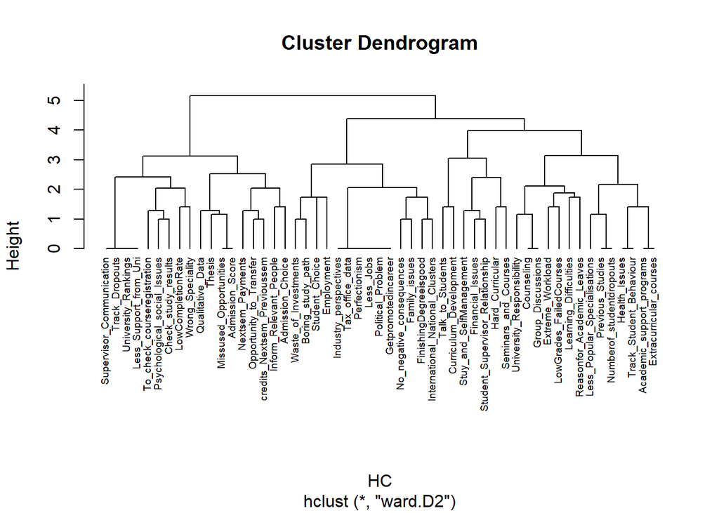

```r
plot(hc1, cex = 0.6, labels = dataClus$Code, hang = -1)
```

make subgroups

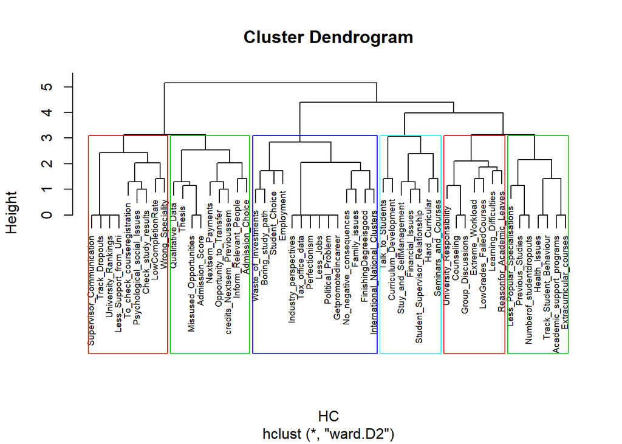

```r
plot(hc1, labels = dataClus$Code, cex = 0.6)
rect.hclust(hc1, k = 6, border = 2:5)
```

Based on the above data clusters were named as follows;

CLuster 1: Learning Aspects Cluster 2 Disposition (Attitude towards study) Cluster 3: Political Aspects Cluster 4: Curriculum Aspects Cluster 5: Institutional Support Cluster 6: Social and behavioural

To idenitfy the most prominent codes based on the frequencies

Here I have considered the all the codes derived from the content analysis (Dropouts as a major concern, Dropout reasons, Strategies Established/Suggested, Data)

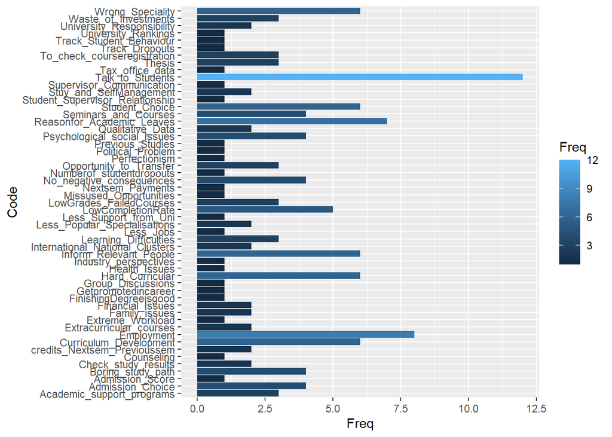

```r
library(ggplot2)
FreqAll <-read.table("./Allfreq.txt", header = TRUE)
ggplot(FreqAll, aes(x=Code, y=Freq,  fill=Freq)) +
geom_bar(stat="identity") +
  coord_flip()
```

ordered plot

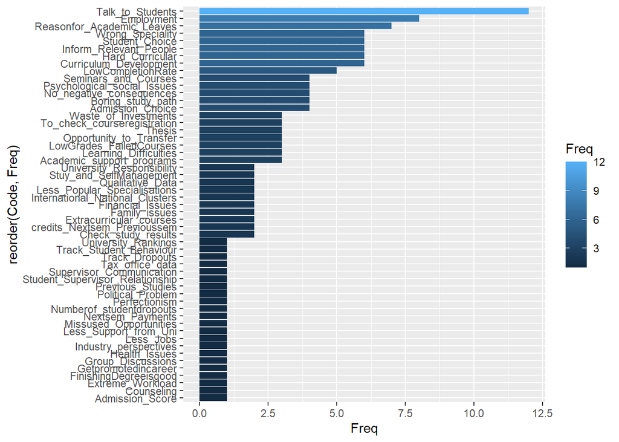

```r
ggplot(FreqAll, aes(x=reorder(Code, Freq), y=Freq,  fill=Freq)) +
geom_bar(stat="identity") +
  coord_flip()
```

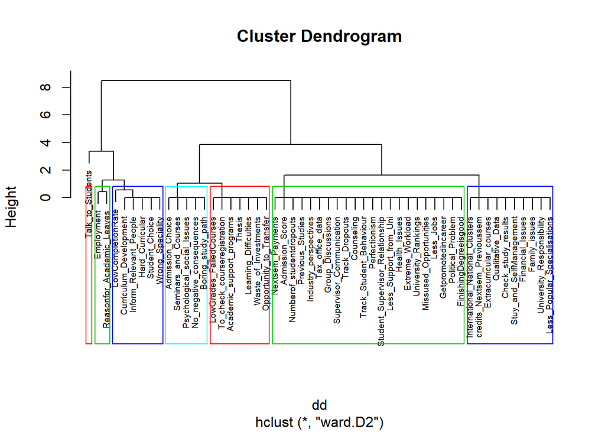

```r
dd <- dist(scale(FreqAll[2]), method = "euclidean")
hc1 <- hclust(dd, method = "ward.D2")
plot(hc1, labels = FreqAll$Code, cex = 0.6)
rect.hclust(hc1, k = 7, border = 2:5)
```

Here I have considered the dropout reasons only

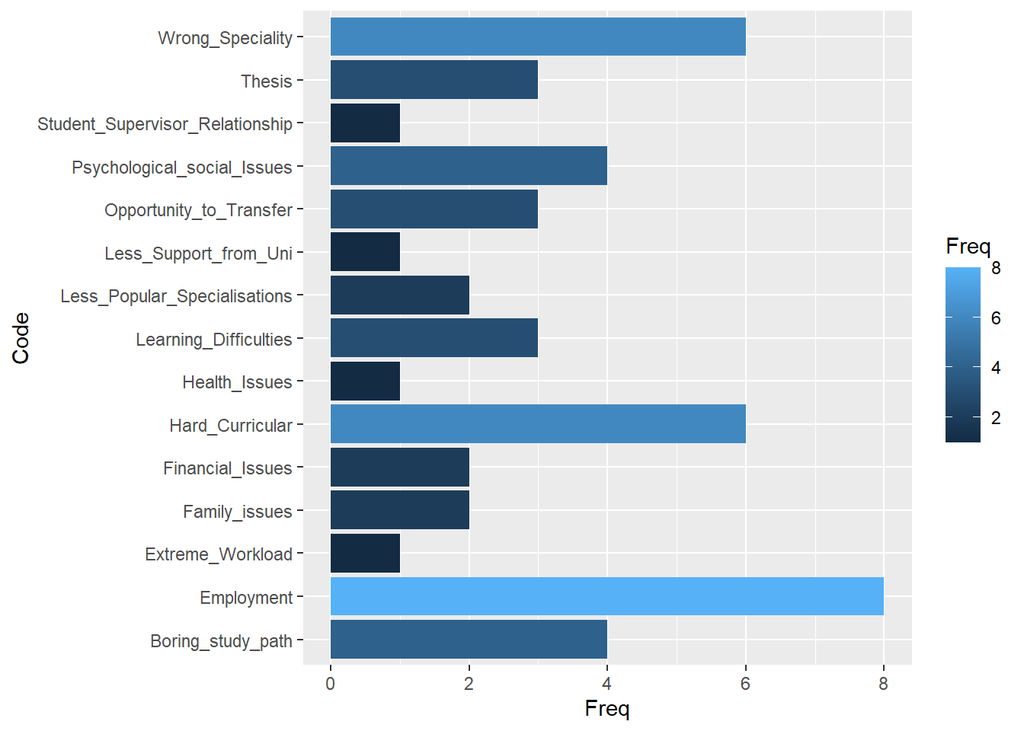

```r
FreqDR <-read.table("./FreqDR.txt", header = TRUE)
ggplot(FreqDR, aes(x=Code, y=Freq,  fill=Freq)) +
geom_bar(stat="identity") +
  coord_flip()
```

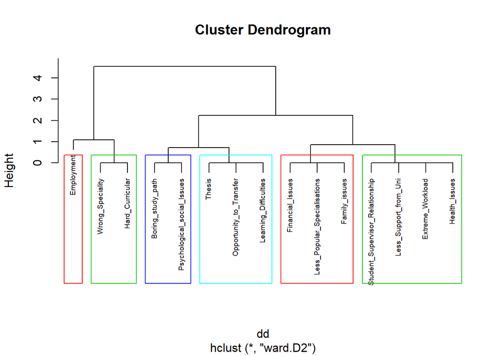

```r
dd <- dist(scale(FreqDR[2]), method = "euclidean")
hc1 <- hclust(dd, method = "ward.D2")
plot(hc1, labels = FreqDR$Code, cex = 0.6)
rect.hclust(hc1, k = 6, border = 2:5)
```